# Categorical predictors

Treatment coding, sum coding and factors

Dr Massimiliano Canzi

# Categorical predictors

`Did you know:` mantis shrimp have 12 types of photoreceptor for colour in their eyes. Humans have three.

*Source: Thoen et al. (2014), Science*

## Today

- What a categorical predictor is, and how R stores it: factors
- Treatment coding: the default in R
- Dummy coding by hand, and changing the reference level
- Sum coding
- Predictors with more than two levels
- Combining categorical and continuous predictors

## So far

Until now every predictor was a number: frequency, length, body mass. Each slope was a change in `y` per unit of `x`.

Many linguistic predictors are categories instead: voicing (voiced, voiceless), speaking style (casual, clear, loud), language, condition, speaker group, word class.

What does “one unit more” mean for `voicing`?

## The data

Vowels are longer before voiced consonants (*bead*) than before voiceless ones (*beat*). A simulated production study:

```r
set.seed(7)
vowels <- tibble(
  voicing  = rep(c("voiceless", "voiced"), each = 60),
  duration = round(c(rnorm(60, 120, 20), rnorm(60, 160, 22)))   # ms
)
vowels |> summarise(mean = mean(duration), sd = sd(duration), n = n(), .by = voicing)
```

```
# A tibble: 2 × 4
  voicing    mean    sd     n
  <chr>     <dbl> <dbl> <int>
1 voiceless  124.  19.7    60
2 voiced     162.  19.8    60
```

## The data

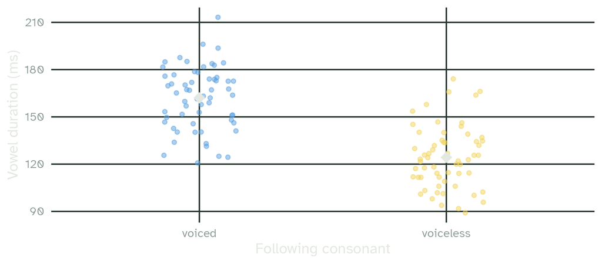

White: the mean of each group. A model with voicing as a predictor should recover these two means.

# Treatment coding

`Did you know:` mantis shrimp come in two kinds: smashers break open crabs, clams and snails with club-like limbs, and spearers ambush fish from their burrows and impale them.

*Source: UC Berkeley News*

## `lm()` with a categorical predictor

```r
m <- lm(duration ~ voicing, data = vowels)
coef(m)
```

```
     (Intercept) voicingvoiceless
       162.06667        -37.76667
```

Compare with the group means:

```r
vowels |> summarise(mean = mean(duration), .by = voicing)
```

```
# A tibble: 2 × 2
  voicing    mean
  <chr>     <dbl>
1 voiceless  124.
2 voiced     162.
```

- The **intercept** is the mean of `voiced`
- The **slope** `voicingvoiceless` is the difference: voiceless minus voiced

## The reference level

Why is `voiced` the intercept?

R turns text into a `factor`, and puts its levels in alphabetical order:

```r
levels(factor(vowels$voicing))
```

```
[1] "voiced"    "voiceless"
```

The first level becomes the **reference level**. Every other level is compared against it.

R names the coefficient `voicingvoiceless`: the predictor, then the level being compared with the reference.

## Treatment coding, visually

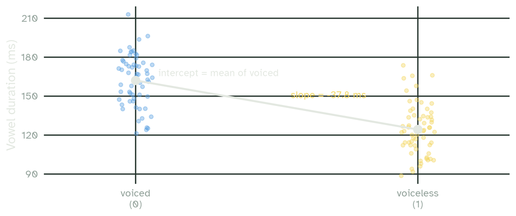

Code the reference level as 0 and the other as 1: the regression line goes through the two means. A one-unit change in x is the change from one category to the other.

## Dummy coding by hand

This is exactly what R does behind the scenes:

```r
vowels <- vowels |>
  mutate(voiceless01 = if_else(voicing == "voiceless", 1, 0))

coef(lm(duration ~ voiceless01, data = vowels))
```

```
(Intercept) voiceless01
  162.06667   -37.76667
```

Same numbers as before. A variable coded 0 and 1 like this is called a **dummy variable**.

## Changing the reference level

Voiceless is the more natural baseline here. Set the order of the levels with `fct_relevel()` from `{forcats}`:

```r
vowels <- vowels |>
  mutate(voicing = fct_relevel(voicing, "voiceless"))

levels(vowels$voicing)
```

```
[1] "voiceless" "voiced"
```

```r
coef(lm(duration ~ voicing, data = vowels))
```

```
  (Intercept) voicingvoiced
    124.30000      37.76667
```

The intercept is now the `voiceless` mean, and the slope is +38 ms for voiced. The model and its fit are unchanged; only the comparison is different.

## Choosing the reference level

- Choose the level that makes the coefficients easiest to read, often a natural baseline: a control condition, the standard variety, the most frequent category
- Set it explicitly, rather than relying on the alphabet

In R, the reference level of a factor is simply its first level.

## Discussion

Your study compares L1 English speakers with three groups of L2 speakers of English, whose first languages are German, Italian and Mandarin.

- Which group would you choose as the reference level, and why?
- Would your choice change if your question were about differences among the three L2 groups?

# Sum coding

`Did you know:` the peacock mantis shrimp strikes snail shells at up to 23 m/s (about 83 km/h), with accelerations of up to 8,000 times gravity. The strike also makes bubbles that collapse with destructive force.

*Sources: Patek, Korff & Caldwell (2004), Nature; UC Berkeley News*

## Sum coding

Instead of 0 and 1, code the two levels as +1 and −1:

```r
contrasts(vowels$voicing) <- contr.sum(2)
contrasts(vowels$voicing)
```

```
          [,1]
voiceless    1
voiced      -1
```

```r
coef(lm(duration ~ voicing, data = vowels))
```

```
(Intercept)    voicing1
  143.18333   -18.88333
```

## Reading sum-coded coefficients

```r
means <- vowels |> summarise(mean = mean(duration), .by = voicing)
mean(means$mean)                      # the mean of the group means
```

```
[1] 143.1833
```

```r
diff(means$mean) / 2                  # half the difference
```

```
[1] 18.88333
```

- The **intercept** is the grand mean: the average of the group means
- The **coefficient** is how far each group lies from that grand mean: `+` for the first level, `−` for the second

## Sum coding, visually

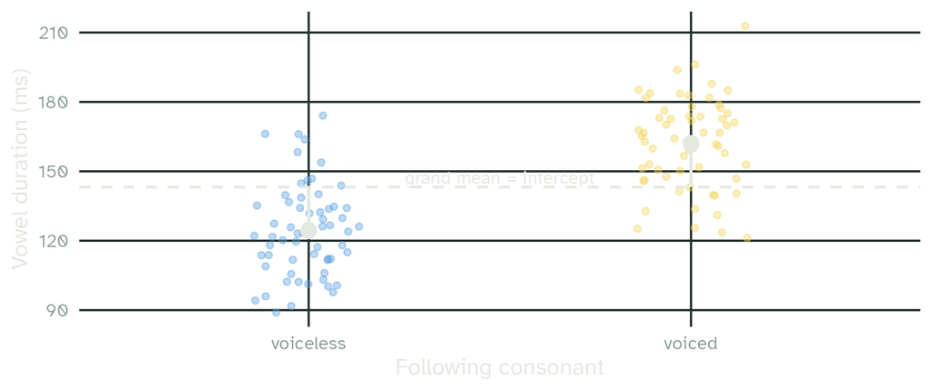

Arrows: the sum-coded coefficient, `±` 18.9 ms from the grand mean.

## Treatment or sum coding?

|  | Treatment (0 / 1) | Sum (+1 / −1) |
| --- | --- | --- |
| Intercept | mean of the reference level | grand mean |
| Coefficient | difference from the reference | deviation from the grand mean |
| Default in R | yes | no: `contr.sum()` |

The fit is identical. The choice changes what the intercept means, which matters most when you add interactions (next week).

# More than two levels

`Did you know:` despite their 12 receptors, mantis shrimp were worse than humans, bees and butterflies at telling similar colours apart. They seem to encode colour unlike any other animal studied: perhaps by recognising colours rather than comparing them.

*Sources: Thoen et al. (2014), Science; Sci.News*

## Speaking style

A simulated study of vowel duration in three speaking styles:

```r
set.seed(9)
styles <- tibble(
  style    = rep(c("casual", "clear", "loud"), each = 50),
  duration = round(c(rnorm(50, 110, 18), rnorm(50, 150, 20), rnorm(50, 132, 19)))
)
styles |> summarise(mean = mean(duration), .by = style)
```

```
# A tibble: 3 × 2
  style   mean
  <chr>  <dbl>
1 casual  108.
2 clear   150.
3 loud    130.
```

## Speaking style

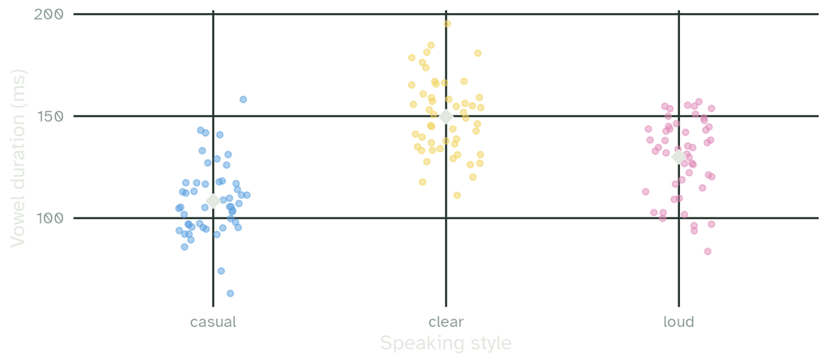

## Three levels, two coefficients

```r
m_style <- lm(duration ~ style, data = styles)
coef(m_style)
```

```
(Intercept)  styleclear   styleloud
     108.34       41.40       21.68
```

The intercept is the mean of `casual`, the reference level. `styleclear` is clear minus casual, and `styleloud` is loud minus casual.

A predictor with `k` levels gets `k − 1` coefficients: each level against the reference.

## Three levels, visually

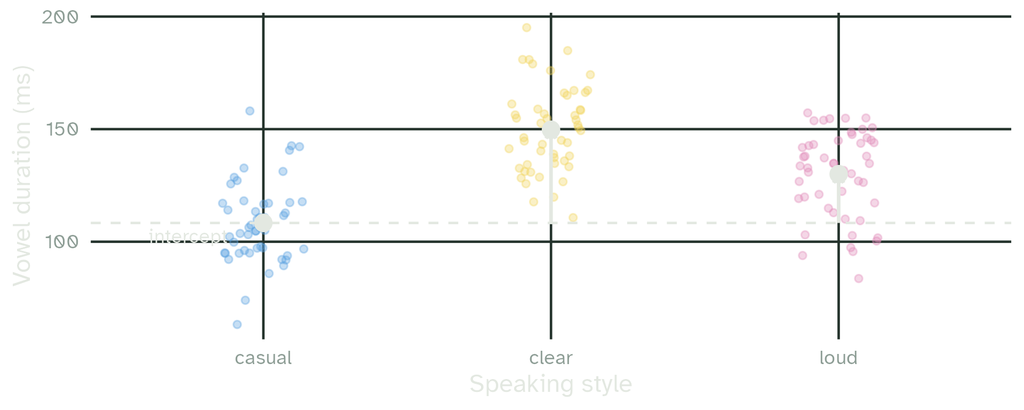

Each arrow is one coefficient: how far clear and loud speech lie from casual speech, the dashed line.

## Behind the scenes

R creates one dummy variable per non-reference level:

```r
model.matrix(~ style, data = styles)[c(1, 51, 101), ]
```

```
    (Intercept) styleclear styleloud
1             1          0         0
51            1          1         0
101           1          0         1
```

| style | styleclear | styleloud | predicted duration |
| --- | --- | --- | --- |
| casual | 0 | 0 | b₀ |
| clear | 1 | 0 | b₀ + b₁ |
| loud | 0 | 1 | b₀ + b₂ |

## What is missing?

The model does not directly compare `clear` with `loud`.

Change the reference level to get that comparison:

```r
styles |>
  mutate(style = fct_relevel(style, "clear")) |>
  lm(duration ~ style, data = _) |>
  coef()
```

```
(Intercept) stylecasual   styleloud
     149.74      -41.40      -19.72
```

`data = _` uses the native pipe’s placeholder: the data come from the pipe.

## Sum coding with three levels

```r
styles <- styles |> mutate(style = factor(style))
contrasts(styles$style) <- contr.sum(3)
coef(lm(duration ~ style, data = styles))
```

```
(Intercept)      style1      style2
  129.36667   -21.02667    20.37333
```

The intercept is now the grand mean of the three styles. `style1` is casual’s deviation from it and `style2` is clear’s. Loud’s deviation is not shown, because it is minus the sum of the other two.

## Model fit and assumptions

```r
glance(m_style)[, 1:2]
```

```
# A tibble: 1 × 2
  r.squared adj.r.squared
      <dbl>         <dbl>
1     0.459         0.451
```

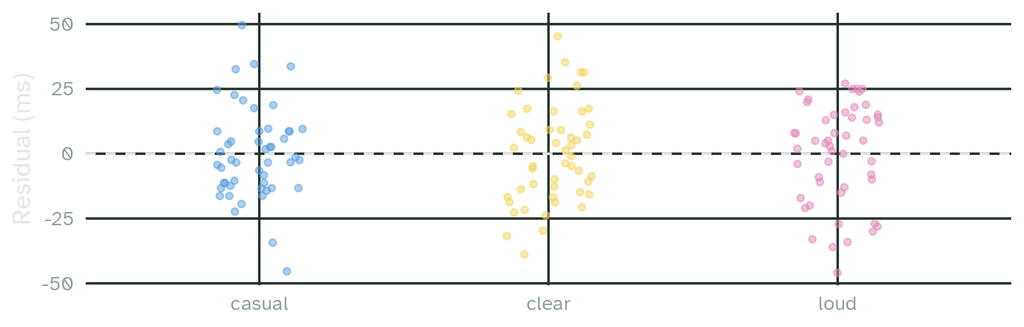

The same assumptions as before. With categories, check that the residuals have a similar spread in every group.

# Mixing predictors

`Did you know:` mantis shrimp were the first animals shown to see circularly polarised light. Some species also reflect it from body parts they display in courtship.

*Source: Chiou et al. (2008), Current Biology*

## Categorical and continuous together

Back to the warning from lecture 4: bill length by bill depth.

```r
bills <- drop_na(penguins, bill_length_mm, bill_depth_mm)
coef(lm(bill_length_mm ~ bill_depth_mm, data = bills))
```

```
  (Intercept) bill_depth_mm
   55.0673698    -0.6498356
```

Add `species` as a second predictor:

```r
m_bills <- lm(bill_length_mm ~ bill_depth_mm + species, data = bills)
coef(m_bills)
```

```
     (Intercept)    bill_depth_mm speciesChinstrap    speciesGentoo
       13.216370         1.394011         9.938955        13.403279
```

With species in the model, the bill depth slope turns positive, as it is within each species.

## Three parallel lines

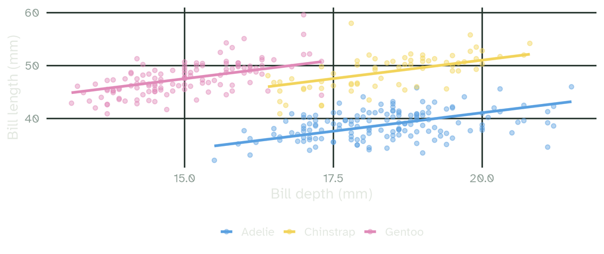

One slope for bill depth, and a different intercept for each species (Adelie is the reference). The lines are parallel: no interaction.

## Reading the mixed model

```r
tidy(m_bills)[, 1:2]
```

```
# A tibble: 4 × 2
  term             estimate
  <chr>               <dbl>
1 (Intercept)         13.2
2 bill_depth_mm        1.39
3 speciesChinstrap     9.94
4 speciesGentoo       13.4
```

| Coefficient | Meaning |
| --- | --- |
| `bill_depth_mm` | 1.39 mm of length per mm of depth, within a species |
| `speciesChinstrap` | Chinstrap bills are 9.9 mm longer than Adelie bills of the same depth |
| `speciesGentoo` | Gentoo bills, 13.4 mm longer |

## Other coding schemes

Treatment and sum coding are the two you will meet most. There are others, for example:

- Helmert coding: each level against the mean of the previous levels
- Successive differences: each level against the previous one, for ordered categories

All of them give the same fit. They differ only in which comparisons the coefficients show: choose the one that matches your research question.

# Your turn

## Exercises

With `penguins`:

1. Model `body_mass_g` by `species`. Check that the coefficients match the group means.
2. Make `Gentoo` the reference level and refit. What changed?
3. Refit with sum coding. What is the intercept now?
4. Model `body_mass_g` by `sex` and `flipper_length_mm` together. Interpret both coefficients.

## Solutions

```r
pengs <- drop_na(penguins, body_mass_g, sex, flipper_length_mm)

coef(lm(body_mass_g ~ species, data = pengs))
```

```
     (Intercept) speciesChinstrap    speciesGentoo
      3706.16438         26.92385       1386.27259
```

```r
pengs |> summarise(mean = mean(body_mass_g), .by = species)
```

```
# A tibble: 3 × 2
  species    mean
  <fct>     <dbl>
1 Adelie    3706.
2 Gentoo    5092.
3 Chinstrap 3733.
```

```r
pengs |>
  mutate(species = fct_relevel(species, "Gentoo")) |>
  lm(body_mass_g ~ species, data = _) |>
  coef()
```

```
     (Intercept)    speciesAdelie speciesChinstrap
        5092.437        -1386.273        -1359.349
```

## Solutions

```r
pengs_sum <- pengs
contrasts(pengs_sum$species) <- contr.sum(3)
coef(lm(body_mass_g ~ species, data = pengs_sum))
```

```
(Intercept)    species1    species2
  4177.2299   -471.0655   -444.1416
```

```r
coef(lm(body_mass_g ~ sex + flipper_length_mm, data = pengs))
```

```
      (Intercept)           sexmale flipper_length_mm
      -5410.30022         347.85025          46.98218
```

Males are about 348 g heavier than females with the same flipper length.

## Summary

- R stores categories as factors; the first level is the reference
- Treatment coding compares each level with the reference; sum coding compares each with the grand mean
- `k` levels → `k − 1` coefficients; change the reference to see other comparisons
- Categorical and continuous predictors can be combined: one slope, several intercepts

## Slides and code

[figure not shown]

These slides

mcanzi.de/ws26_statistics/07_categorical_predictors.html

Code, data and all lectures

github.com/mcanzi/ws26_statistics